# Analiza Factorială (AF)

Analiza Factorială este o tehnică statistică utilizată pentru a identifica structura ascunsă a datelor. Ea pornește de la premisa că variațiile variabilelor observate (cele 13 specificații tehnice) sunt determinate de un număr mai mic de **factori latenți** (nevăzuți).

- Scopul principal este de a descoperi "cauzelor profunde" care explică de ce anumite variabile sunt corelate între ele.
- De exemplu, variabilele observate *"Viteză maximă"*, *"Accelerație 0-100"* și *"Putere CP"* sunt puternic corelate deoarece în spatele lor stă un singur factor latent: *"Performanța Sportivă"*. AF ne ajută să găsim și să cuantificăm acest factor.
- Spre deosebire de ACP (care doar comprimă datele matematic), Analiza Factorială modelează relațiile de cauzalitate dintre concepte abstracte și măsuri concrete.

```python
import numpy as np
from factor_analyzer import FactorAnalyzer,calculate_kmo,calculate_bartlett_sphericity
import pandas as pd
import sys
from utils import *
import matplotlib.pyplot as plt
import seaborn as sb

masini=pd.read_csv('SET DE DATE/Specificatii masini 2023.csv',index_col=(0,1))
replaceNan(masini)
variabile=masini.columns[2:].tolist()
x=masini[variabile].values
masini.tail()
```

| Company | Model | Segment | Fuel | Power(HP) | Torque(Nm) | Displacement | Length | Width | Height | Wheelbase | Cargo Volume | Unladen Weight | Top Speed | Acceleration 0-62 Mph (0-100 kph) | Combined mpg | Fuel capacity |
| --- | --- | --- | --- | --- | --- | --- | --- | --- | --- | --- | --- | --- | --- | --- | --- | --- |
| VOLVO | VOLVO V60 (2018-Present) | Medium | Diesel | 150.0 | 350.0 | 1969.0 | 187.4 | 72.8 | 56.2 | 113.1 | 18.7 | 3737.0 | 127.0 | 9.6 | 42.8 | 15.9 |
|  | VOLVO V60 (2018-Present) | Medium | Diesel | 190.0 | 400.0 | 1969.0 | 187.4 | 72.8 | 56.2 | 113.1 | 18.7 | 3737.0 | 137.0 | 7.9 | 43.6 | 15.9 |
|  | VOLVO V60 (2018-Present) | Medium | Diesel | 190.0 | 400.0 | 1969.0 | 187.4 | 72.8 | 56.2 | 113.1 | 18.7 | 3737.0 | 137.0 | 7.9 | 43.6 | 15.9 |
|  | VOLVO V60 (2018-Present) | Medium | Diesel | 190.0 | 400.0 | 1969.0 | 187.4 | 72.8 | 56.2 | 113.1 | 18.7 | 3737.0 | 137.0 | 7.6 | 42.8 | 15.9 |
|  | VOLVO XC60 (2017-Present) | Crossover | Diesel | 190.0 | 400.0 | 1969.0 | 184.6 | 78.7 | 65.3 | 112.8 | 17.8 | 4211.0 | 127.0 | 8.4 | 45.2 | 15.9 |

## Teste de compatibilitate

1. **Testul Bartlett de Sfericitate:**
   - Verifică ipoteza nulă că variabilele sunt necorelate (matricea de corelație este identitate).
   - Un *p-value < 0.05* (semnificativ statistic) ne indică faptul că putem respinge ipoteza nulă. Există corelații semnificative între variabile, deci analiza factorială are sens.

```python
chi2,p_value=calculate_bartlett_sphericity(x)
print(f'Chi patrat: {chi2}\nP-value: {p_value}')
if p_value<0.05:
    print('H(0): variabilele sunt independente (RESPINS)')
    print('H(1): variabilele nu sunt independente (ACCEPT)')
else:
    print('H(0): variabilele sunt independente (ACCEPT)')
    print('H(1): variabilele nu sunt independente (RESPINS)')
    print('NU se poate analiza factoriala')
    sys.exit(-10)
```

```
Chi patrat: 21307.496873279426
P-value: 0.0
H(0): variabilele sunt independente (RESPINS)
H(1): variabilele nu sunt independente (ACCEPT)
```

2. **Indicele KMO (Kaiser-Meyer-Olkin):**
   - Măsoară adecvarea eșantionării per ansamblu.
   - O valoare *KMO > 0.6* indică faptul că datele sunt foarte potrivite pentru analiză. Dacă valoarea ar fi sub 0.5, analiza factorială nu se poate face.

```python
kmo_all,kmo_overall=calculate_kmo(x)
print(f'\nValoarea testului KMO: {kmo_overall}')
if kmo_overall>0.6:
    print(f'Si testul kmo a trecut ({np.round(kmo_overall,3)}>0.6). Se poate aplica analiza factoriala')
else:
    print(f'Valoarea testului kmo este prea mica({np.round(kmo_overall,3)}<0.6). Nu se poate aplica analiza factoriala')
    sys.exit(-1)
```

```
Valoarea testului KMO: 0.8810887211891298
Si testul kmo a trecut (0.881>0.6). Se poate aplica analiza factoriala
```

## Gasirea numarului de factori latenti

Folosind *Criteriul Kaiser* (valori proprii > 1), determinăm câți factori latenți sunt necesari pentru a explica structura datelor.

- O valoare proprie (eigenvalue) reprezintă cantitatea de informație conținută într-un factor. Dacă valoarea este > 1, înseamnă că acel factor explică mai multă variație decât o singură variabilă originală, deci merită păstrat.
- Codul ne indică numărul optim de factori pe care să îi extragem pentru modelul final.

```python
fa_n=FactorAnalyzer(rotation=None)
fa_n.fit(x)

valori_proprii,_=fa_n.get_eigenvalues()

conditie=np.where(valori_proprii>1)
n_factori=len(conditie[0])
print(f'In setul de date exista {n_factori} factori latenti')
```

```
In setul de date exista 2 factori latenti
```

## Initializarea modelului propriu zis si gasirea scorurilor

- Transformă (rotește) axele factoriale pentru a le face interpretabile. Fiecare variabilă va contribui majoritar la un singur factor, nu la toți.
- Obținem scoruri clare pentru fiecare mașină pe noile axe latente (F1, F2...), permițând identificarea profilului fiecărui model.

```python
fa=FactorAnalyzer(n_factors=n_factori,rotation='varimax')
fa.fit(x)
eticheteFactori=['F'+str(i+1) for i in range(n_factori)]

scoruri=fa.transform(x)
scoruriDf=toDataFrame(scoruri,masini.index,eticheteFactori,'Scoruri.csv')
scoruriDf.tail(25)
```

| Company | Model | F1 | F2 |
| --- | --- | --- | --- |
| VOLVO | VOLVO V90 (2019-Present) | 0.431711 | 0.623354 |
|  | VOLVO V90 (2019-Present) | 0.830066 | -0.044280 |
|  | VOLVO V90 Cross Country (2019-Present) | 0.274745 | 0.915616 |
|  | VOLVO V90 Cross Country (2019-Present) | 0.448533 | 0.842393 |
|  | VOLVO V90 Cross Country (2019-Present) | -0.143436 | 1.206365 |
|  | VOLVO V90 Cross Country (2019-Present) | -0.143436 | 1.206365 |
|  | VOLVO V90 Cross Country (2019-Present) | -0.033611 | 1.196742 |
|  | VOLVO V60 Cross Country (2018-Present) | 0.308503 | 0.758289 |
|  | VOLVO V60 Cross Country (2018-Present) | -0.495834 | 1.323786 |
|  | VOLVO V60 Cross Country (2018-Present) | -0.110036 | 1.052029 |
|  | VOLVO S60 (2018-Present) | 0.117452 | 0.444243 |
|  | VOLVO S60 (2018-Present) | 0.534845 | 0.174225 |
|  | VOLVO S60 (2018-Present) | 0.540567 | 0.168634 |
|  | VOLVO S60 (2018-Present) | 0.838035 | 0.002445 |
|  | VOLVO S60 (2018-Present) | 0.932154 | -0.480847 |
|  | VOLVO V60 (2018-Present) | 0.056387 | 0.525459 |
|  | VOLVO V60 (2018-Present) | 0.400004 | 0.317220 |
|  | VOLVO V60 (2018-Present) | 0.410688 | 0.312395 |
|  | VOLVO V60 (2018-Present) | -0.359143 | 0.818497 |
|  | VOLVO V60 (2018-Present) | -0.360618 | 0.830839 |
|  | VOLVO V60 (2018-Present) | -0.324612 | 0.813476 |
|  | VOLVO V60 (2018-Present) | 0.084228 | 0.519999 |
|  | VOLVO V60 (2018-Present) | 0.084228 | 0.519999 |
|  | VOLVO V60 (2018-Present) | 0.101036 | 0.506216 |
|  | VOLVO XC60 (2017-Present) | -0.160988 | 1.153891 |

**Concluzie:** Analiza Factorială a "înțeles" perfect gama Volvo. Fără să știe ce e un "Sedan" sau un "SUV", a ordonat mașinile logic pe axa F2: **S60 < V60 < XC60/Cross Country**.

## Comunalitati si varianta specifica

- *Comunalități:* Reprezintă procentul din variația fiecărei variabile (ex: "Consum", "Putere") care este explicat de factorii comuni de bază. Valori apropiate de 1 indică o reprezentare bună în model.
- *Varianță Specifică:* Este partea de informație care rămâne unică variabilei sau eroare de măsurare (neexplicată de factori). Este complementul comunalității ($1 - h^2_j$). Valorile mici sunt ideale.

```python
comunalitati=fa.get_communalities()
varianta_specifica=1-comunalitati
comunalitatiDf=toDataFrame(comunalitati,variabile,['Comunalitati'],'Comunalitati.csv')
comunalitatiDf['Varianta specifica']=varianta_specifica
comunalitatiDf.to_csv('Comunalitati si varianta specifica.csv')
comunalitatiDf.head(13)
```

|  | Comunalitati | Varianta specifica |
| --- | --- | --- |
| Power(HP) | 0.770771 | 0.229229 |
| Torque(Nm) | 0.763867 | 0.236133 |
| Displacement | 0.753760 | 0.246240 |
| Length | 0.775964 | 0.224036 |
| Width | 0.489892 | 0.510108 |
| Height | 0.442378 | 0.557622 |
| Wheelbase | 0.793208 | 0.206792 |
| Cargo Volume | 0.434020 | 0.565980 |
| Unladen Weight | 0.872736 | 0.127264 |
| Top Speed | 0.856839 | 0.143161 |
| Acceleration 0-62 Mph (0-100 kph) | 0.787517 | 0.212483 |
| Combined mpg | 0.176178 | 0.823822 |
| Fuel capacity | 0.675679 | 0.324321 |

- **Variabile Bine Explicate (Comunalitate > 0.75):**
  - *Unladen Weight (0.87), Top Speed (0.85), Wheelbase (0.79), Power (0.77).*
  - Modelul este excelent în a surprinde esența *Performanței* și a *Dimensiunilor*. Practic, dacă știm Factorii F1 și F2, putem estima cu mare precizie greutatea sau viteza unei mașini.
- **Variabile Slab Explicate (Varianta Specifică Mare):**
  - *Combined mpg (Consumul):* Are o variantă specifică uriașă de *0.82* (doar 0.17 comunalitate).
  - Consumul de combustibil NU depinde doar de Putere și Mărime. El este influențat masiv de alți factori pe care modelul acesta nu îi vede (tehnologie hibridă, aerodinamică avansată, eficiența cutiei de viteze). Consumul este o variabilă "unică", independentă.
  - *Cargo Volume (Portbagajul):* Varianta specifică *0.56*. Volumul portbagajului nu crește automat odată cu dimensiunea mașinii; depinde mult de designul specific (ex: un sedan lung poate avea portbagaj mai mic decât un hatch scurt dar înalt).

## Varianta

```python
varianta_individuala,varianta_prop,varianta_cumulata=fa.get_factor_variance()
varDf=pd.DataFrame({
    'Varianta':varianta_individuala,
    'Varianta proportionala':varianta_prop,
    'Varianta cumulata':varianta_cumulata
},index=eticheteFactori)
varDf.head(2)
```

|  | Varianta | Varianta proportionala | Varianta cumulata |
| --- | --- | --- | --- |
| F1 | 5.418522 | 0.416809 | 0.416809 |
| F2 | 3.174287 | 0.244176 | 0.660985 |

1. **Varianta Proporțională:**
   - **F1 (41.6%):** Primul factor explică singur aproape jumătate din diferențele dintre mașini. Adică, dacă știi doar "Cât de performantă e mașina", știi deja 41% din tot ce e de știut despre ea.
   - **F2 (24.4%):** Al doilea factor adaugă încă un sfert din informație, explicând diferențele de gabarit/caroserie.
2. **Varianta Cumulată (Totalul):**
   - **0.66 (66%):** Împreună, F1 și F2 explică **66%** din variația totală a setului de date.
   - *Verdict:* Este un rezultat decent (acceptabil > 60%). Celelalte 34% din diferențe sunt detalii fine (design specific, consum, brand) care s-au pierdut prin simplificare, dar "harta generală" a pieței este corectă în proporție de două treimi.

## Loadings (corelatii factoriale)

Această matrice arată corelația dintre fiecare variabilă originală și factorii extrași.

- *Valori mari (> 0.5):* Indică o legătură puternică. Variabila "aparține" acelui factor.
- *Semnul (+/-):* Indică direcția relației (ex: corelație pozitivă sau negativă).
- *Utilizare:* Pe baza variabilelor cu încărcări mari, putem da "nume" factorilor.

```python
loadings=fa.loadings_
loadingsDf=toDataFrame(loadings,variabile,eticheteFactori,'Loadings.csv')
loadingsDf.head(13)
```

|  | F1 | F2 |
| --- | --- | --- |
| Power(HP) | 0.870787 | 0.111811 |
| Torque(Nm) | 0.821422 | 0.298550 |
| Displacement | 0.838958 | 0.223405 |
| Length | 0.514857 | 0.714763 |
| Width | 0.483013 | 0.506548 |
| Height | -0.219244 | 0.627942 |
| Wheelbase | 0.447393 | 0.770096 |
| Cargo Volume | -0.034843 | 0.657880 |
| Unladen Weight | 0.622257 | 0.696801 |
| Top Speed | 0.924956 | -0.035991 |
| Acceleration 0-62 Mph (0-100 kph) | -0.887012 | -0.026970 |
| Combined mpg | -0.409025 | -0.094218 |
| Fuel capacity | 0.580522 | 0.581956 |

**F1: Factorul de Performanță Dinamică (Motor & Viteză)**

- Are corelații foarte puternice cu: *Viteză Maximă (0.92)*, *Accelerație (-0.88)*, *Putere (0.87)*, *Cuplu (0.82)*.
- Corelația negativă cu accelerația este logică: cu cât mașina e mai performantă (F1 mare), cu atât timpul 0-100 scade.
- F1 separă mașinile lente de cele super-sportive, indiferent de mărime.

**F2: Factorul de Gabarit și Utilitate (Caroserie & Dimensiuni)**

- Dominat de variabilele de dimensiune: *Ampatament (0.77)*, *Lungime (0.71)*, *Greutate (0.69)*, *Volum Portbagaj (0.65)*, *Înălțime (0.62)*.
- Are corelații aproape zero cu Viteza și Accelerația.
- F2 separă mașinile mici/compacte de SUV-uri și limuzine mari.

**Concluzie:** Rotația Varimax a separat perfect "Ce poate mașina" (F1 - Motor) de "Cât de mare e mașina" (F2 - Caroserie), mult mai clar decât în ACP!

## Grafice

### Scree plot al valorilor proprii

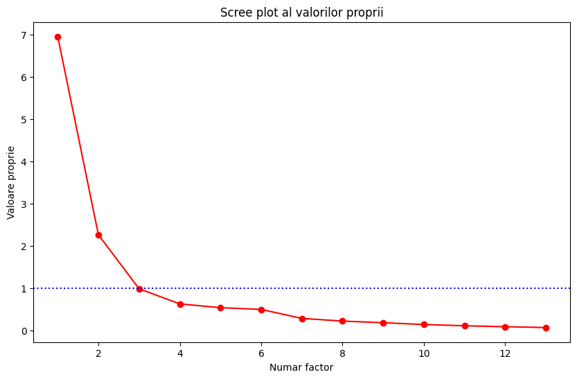

```python
plt.figure(figsize=(10,6))
plt.title('Scree plot al valorilor proprii')
plt.plot(range(1,len(valori_proprii)+1),valori_proprii,'ro-')
plt.axhline(y=1,color='blue',linestyle=':')
plt.xlabel('Numar factor')
plt.ylabel('Valoare proprie');
```

Acest grafic vizualizează importanța fiecărui factor potențial.

- Valoarea Proprie (Eigenvalue) – cantitatea de informație.
- Pragul critic de 1 (Criteriul Kaiser).
- Reținem doar factorii care se află **deasupra liniei punctate** și până unde apare "cotul" (schimbarea bruscă de pantă). În cazul nostru, observăm clar **2 factori dominanți** (F1 și F2).

### Heatmap corelatia dintre factori si variabilele principale

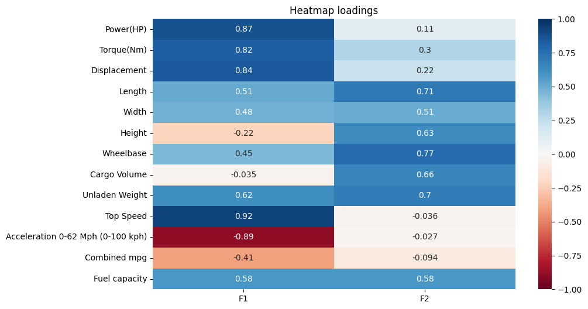

```python
plt.figure(figsize=(10,6))
plt.title('Heatmap loadings')
plt.xlabel('Factori')
plt.ylabel('Variabilele modelului')
sb.heatmap(loadingsDf,vmin=-1,vmax=1,cmap='RdBu',annot=True);
```

Vizualizarea confirmă perfect separarea variabilelor:

- **Coloana F1 (Stânga):** Este dominată de culori albastre închise (corelații pozitive) pentru *Performanță* (Putere, Viteză, Cuplu) și roșu închis (corelație negativă) pentru *Accelerație*.
- **Coloana F2 (Dreapta):** Este dominată de albastru pentru *Dimensiuni* (Lungime, Ampatament, Greutate).
- **Zona mediană:** Variabile precum *Capacity* sau *Mpg* au culori mai șterse, indicând o influență mixtă sau mai slabă asupra factorilor principali.

### Scatter pentru scoruri

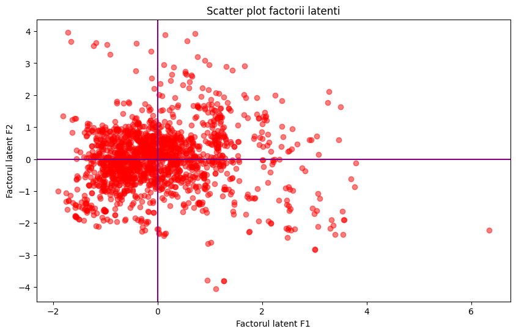

```python
plt.figure(figsize=(10,6))
plt.title('Scatter plot factorii latenti')
plt.scatter(scoruriDf['F1'],scoruriDf['F2'],alpha=0.5,color='red')
plt.xlabel('Factorul latent F1')
plt.ylabel('Factorul latent F2')
plt.axhline(y=0,color='purple')
plt.axvline(x=0,color='purple');
```

Acest grafic arată poziția fiecărei mașini în noul spațiu definit de cei doi factori:

- **Axa Orizontală (F1 - Performanță):** În dreapta sunt mașinile extrem de rapide și puternice, în stânga cele economice.
- **Axa Verticală (F2 - Gabarit):** Sus sunt mașinile mari și grele (SUV-uri, Limuzine), jos sunt cele mici și ușoare. **Interpretarea Cadraniilor:**
1. **Dreapta-Jos (Performanță Mare, Gabarit Mic):** Aici găsim *Supercar-urile pure* (rapide și agile).
2. **Dreapta-Sus (Performanță Mare, Gabarit Mare):** Aici sunt *SUV-urile de Lux* și Limuzinele puternice (rapide, dar masive).
3. **Stânga-Jos (Performanță Mică, Gabarit Mic):** Mașinile de *Oraș (City Cars)* economice.

### Heat map cu varianta specifica

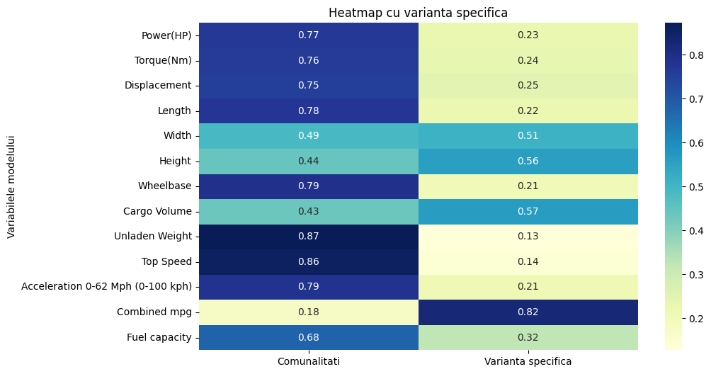

```python
plt.figure(figsize=(10,6))
plt.title('Heatmap cu varianta specifica')
sb.heatmap(comunalitatiDf,cmap='YlGnBu',annot=True)
plt.ylabel('Variabilele modelului');
```

Acest grafic ne spune **cât de bine** este explicată fiecare variabilă de modelul nostru factorial:

- **Comunalități Mari (Albastru Închis):** Variabilele *Putere (0.77), Lungime (0.78), Greutate (0.87), Viteză (0.86)* sunt explicate excelent de model. Factorii latenți surprind aproape toată informația lor.
- **Comunalități Mici (Galben/Deschis):** Variabila *Combined mpg (0.18)* este o excepție majoră. Are o varianță specifică uriașă (0.82), ceea ce înseamnă că *consumul* nu este explicat bine de factorii "Performanță" sau "Mărime". Este un fenomen distinct, influențat probabil de tehnologie (hibrid/electric), nu doar de mărime sau putere.

### Cercul corelatiilor

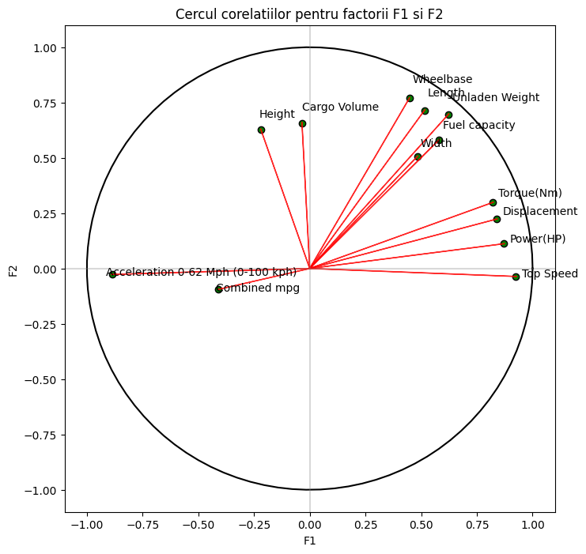

```python
plt.figure(figsize=(8,8))
x_coords=loadings[:,0]
y_coords=loadings[:,1]

plt.title('Cercul corelatiilor pentru factorii F1 si F2')
plt.scatter(x_coords,y_coords,color='green',edgecolors='black')

theta=np.linspace(0,2*np.pi,100)
plt.plot(np.cos(theta),np.sin(theta),color='black',linestyle='-')

for i in range(len(variabile)):
    plt.arrow(0,0,x_coords[i],y_coords[i],alpha=0.8,color='red')
    plt.annotate(variabile[i],(x_coords[i]*1.03,y_coords[i]*1.09))

plt.xlim(-1.1,1.1)
plt.ylim(-1.1,1.1)

plt.axhline(y=0,color='gray',alpha=0.3)
plt.axvline(x=0,color='gray',alpha=0.3)

plt.xlabel('F1')
plt.ylabel('F2');
```

Acest grafic arată vizual relațiile dintre variabile și noile axe factoriale: